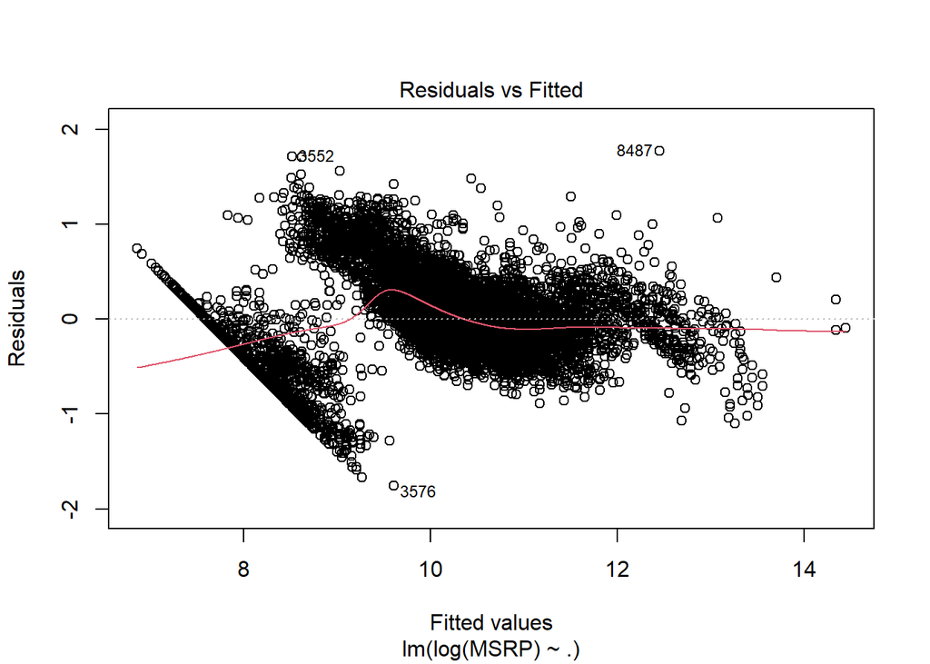

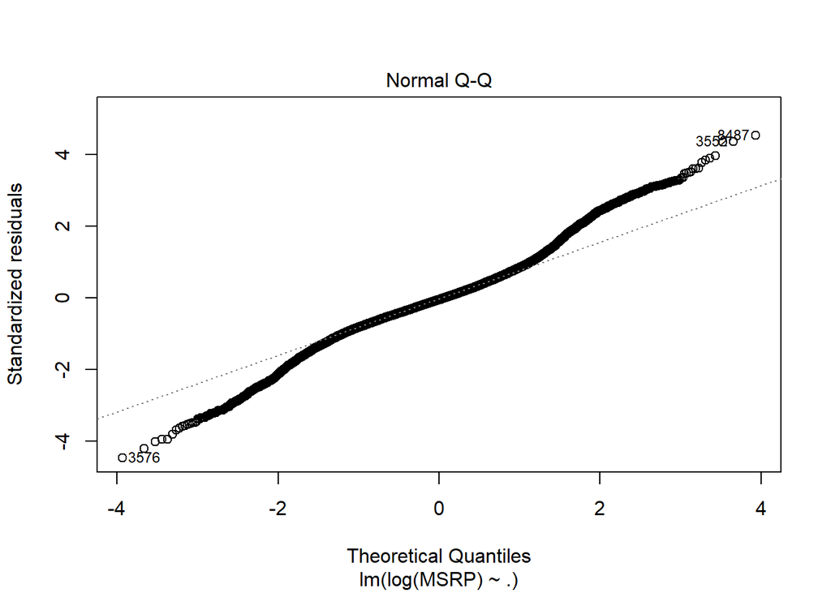

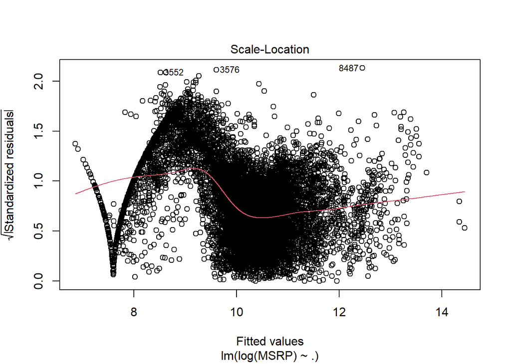

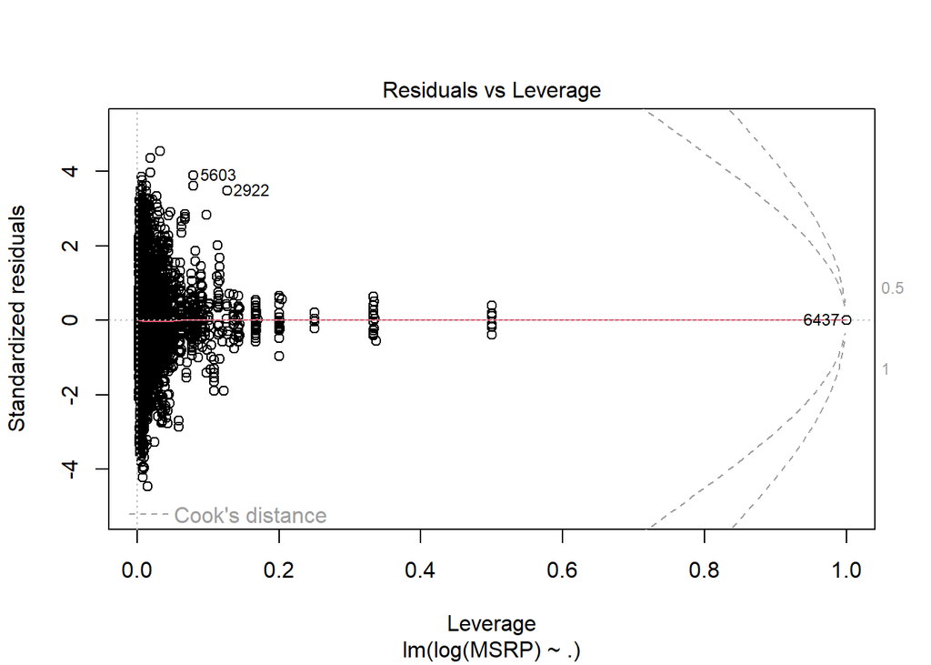

```r
car_glm<- car_data[,!names(car_data) %in% c("Engine.Cylinders6","city.mpg","Chrysler",
                                            "Ford","Hummer","Infiniti","Mazda","Volkswagen","natural",
                                            "prem_rec","front_drive","auto_manual","two_door","fourdr_SUV")]

model_2 <- lm(log(MSRP)~.,car_glm)
plot(model_2)
```

#### Correlation plot

Based on the correlation plot below we can see that the variables with the highest correlation with MSRP are Engine.HP and Engine.Cylinders.

Log MSRP seems to have a stronger correlation with Year and also includes Engine.HP, Engine.Cylinders

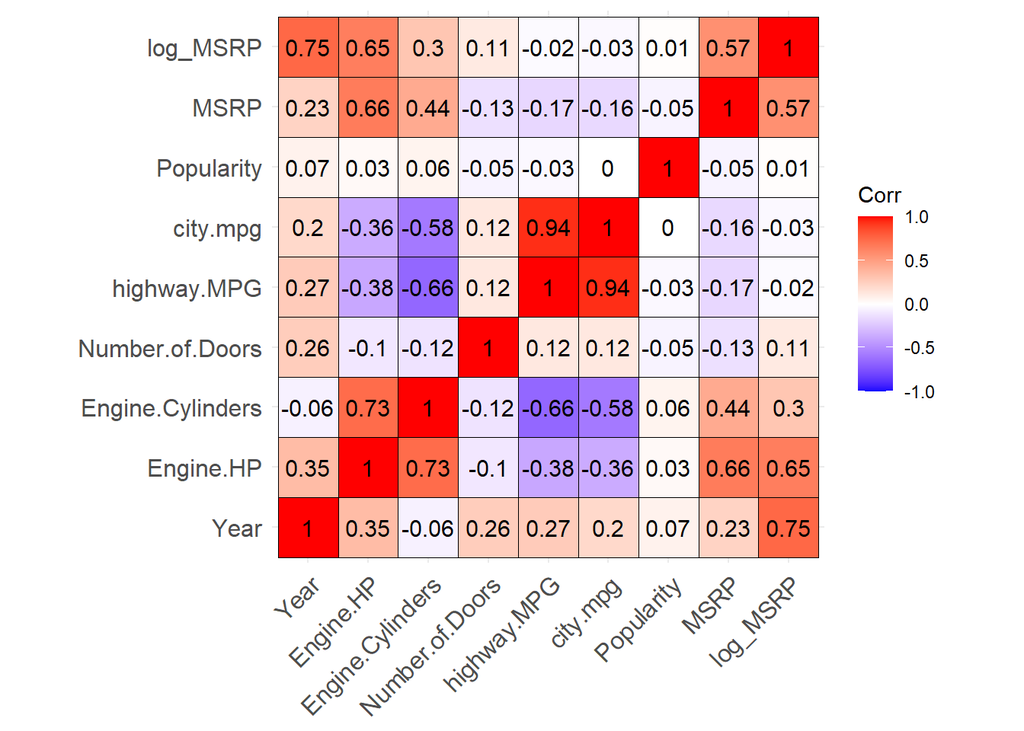

```r
library(ggcorrplot)

car_data_correlations <- car_data[,-c(1, 3, 6, 7,9,10,11)]

car_data_correlations$Engine.HP <- as.integer(car_data_correlations$Engine.HP)
car_data_correlations$Engine.Cylinders<-as.integer(car_data_correlations$Engine.Cylinders)
car_data_correlations$highway.MPG<-as.integer(car_data_correlations$highway.MPG)
car_data_correlations$log_MSRP <- as.integer(log(car_data_correlations$MSRP))

corr_data <- cor(car_data_correlations)


ggcorrplot(corr_data, outline.color = "black", lab = TRUE)
```

General Model Creation

```r
library(car)
car_model_fit <- lm(log_MSRP~Year+Engine.Cylinders+Engine.HP,car_data_correlations)

summary(car_model_fit)
```

```
##
## Call:
## lm(formula = log_MSRP ~ Year + Engine.Cylinders + Engine.HP,
##     data = car_data_correlations)
##
## Residuals:
##      Min       1Q   Median       3Q      Max
## -2.08694 -0.41136 -0.04019  0.37683  2.87638
##
## Coefficients:
##                    Estimate Std. Error  t value Pr(>|t|)
## (Intercept)      -1.820e+02  1.810e+00 -100.586  < 2e-16 ***
## Year              9.472e-02  8.991e-04  105.350  < 2e-16 ***
## Engine.Cylinders  4.047e-02  7.117e-03    5.686 1.33e-08 ***
## Engine.HP         4.286e-03  9.166e-05   46.759  < 2e-16 ***
## ---
## Signif. codes:  0 '***' 0.001 '**' 0.01 '*' 0.05 '.' 0.1 ' ' 1
##
## Residual standard error: 0.6054 on 11910 degrees of freedom
## Multiple R-squared:  0.733,  Adjusted R-squared:  0.733
## F-statistic: 1.09e+04 on 3 and 11910 DF,  p-value: < 2.2e-16
```

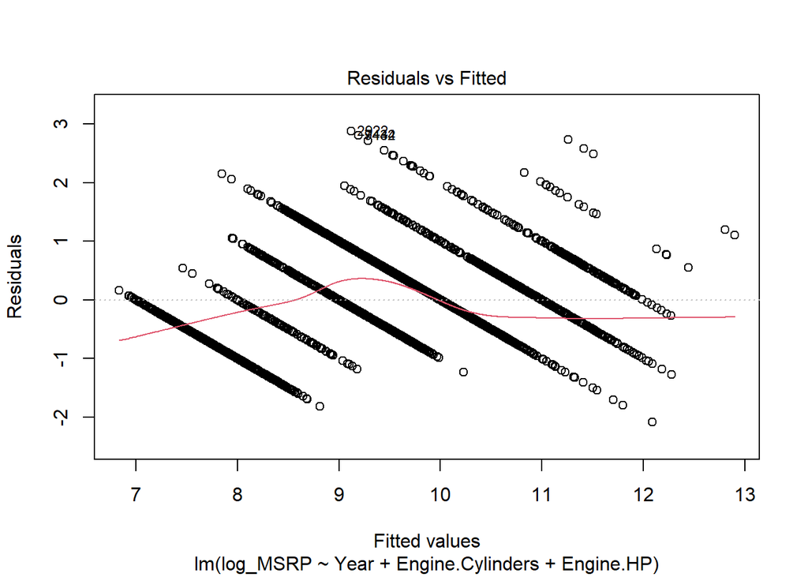

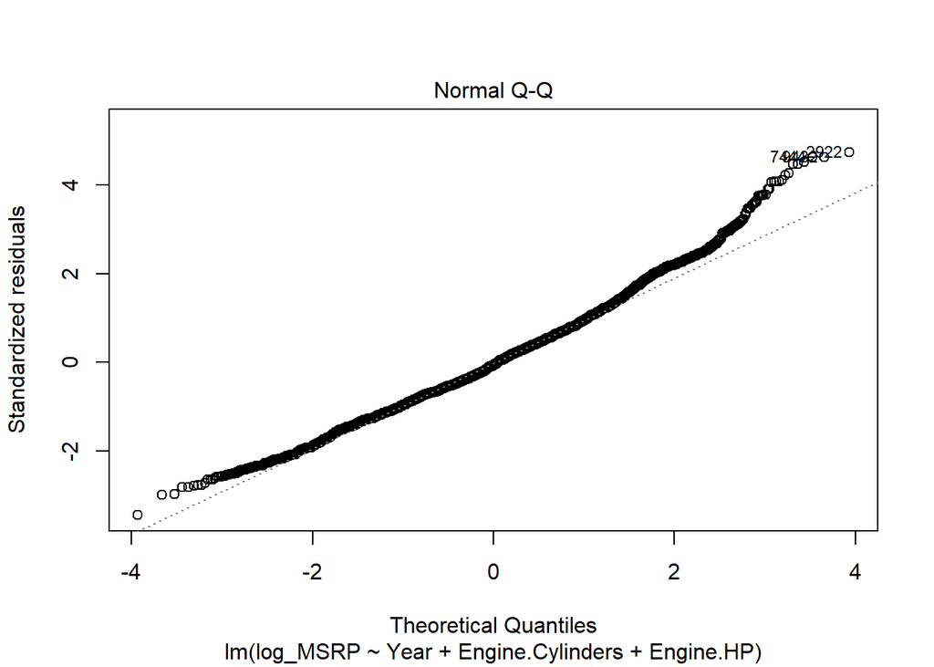

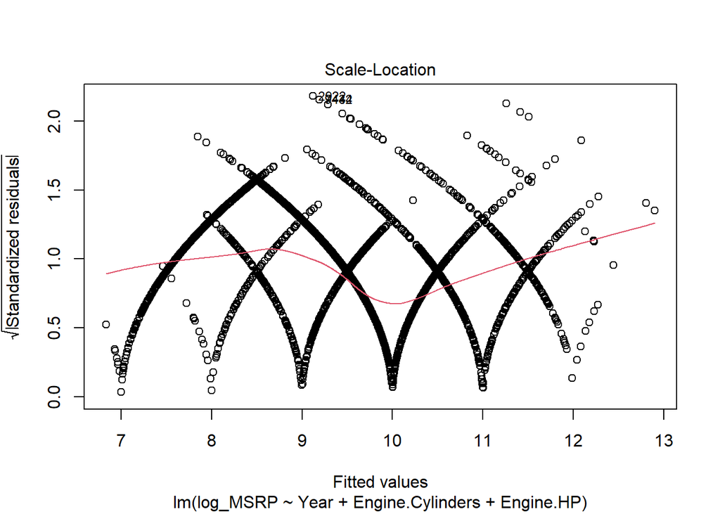

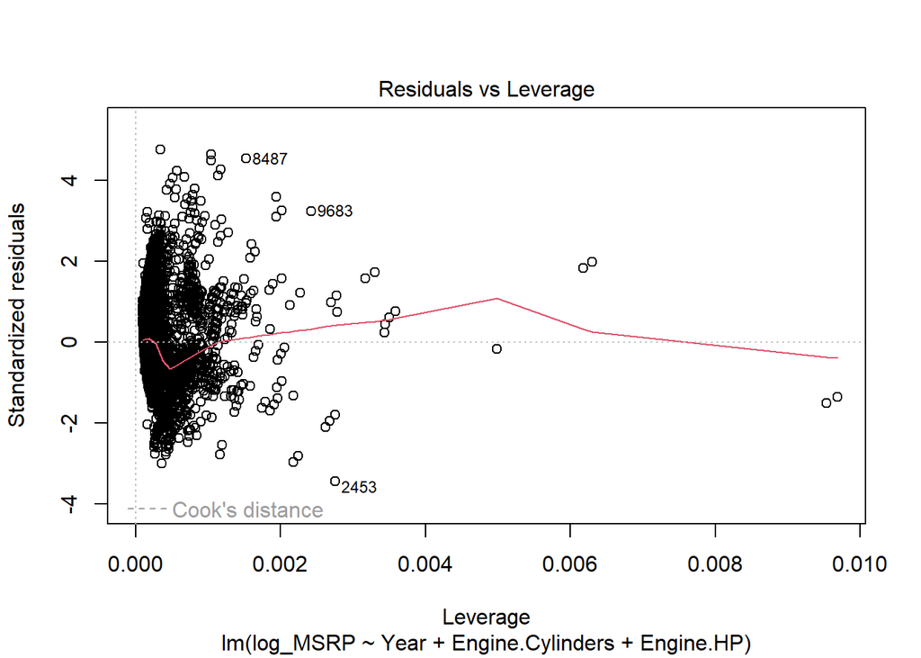

```r
plot(car_model_fit)
```

```r
vif(car_model_fit)
```

```
##             Year Engine.Cylinders        Engine.HP
##         1.509405         2.878820         3.269147
```

categorical variable encoding

```r
car_data$BMW <- ifelse(car_data$Make == "BMW",1,0) # if bmw then 1 else(not) 0
car_data$Audi <- ifelse(car_data$Make=="Audi",1,0)
car_data$FIAT <- ifelse(car_data$Make=="FIAT",1,0)
car_data$Mercedes <- ifelse(car_data$Make=="Mercedes-Benz",1,0)
car_data$Acura <- ifelse(car_data$Make=="Acura",1,0)
car_data$Alfa_Romeo <- ifelse(car_data$Make=="Alfa Romeo",1,0)
car_data$Aston_Martin <- ifelse(car_data$Make=="Aston Martin",1,0)
car_data$Bentley <- ifelse(car_data$Make=="Bentley",1,0)
car_data$Bugatti <- ifelse(car_data$Make=="Bugatti",1,0)
car_data$Buick <- ifelse(car_data$Make=="Buick",1,0)
car_data$Cadillac <- ifelse(car_data$Make=="Cadillac",1,0)
car_data$Chevrolet <- ifelse(car_data$Make=="Chevrolet",1,0)
car_data$Chrysler <- ifelse(car_data$Make=="Chrysler",1,0)
car_data$Dodge <- ifelse(car_data$Make=="Dodge",1,0)
car_data$Ferrari <- ifelse(car_data$Make=="Ferrari",1,0)
car_data$Ford <- ifelse(car_data$Make=="Ford",1,0)
car_data$Genesis <- ifelse(car_data$Make=="Genesis",1,0)
car_data$GMC <- ifelse(car_data$Make=="GMC",1,0)
car_data$Honda <- ifelse(car_data$Make=="Honda",1,0)
car_data$Land_Rover <- ifelse(car_data$Make=="Land Rover",1,0)
car_data$Lamborghini <- ifelse(car_data$Make=="Lamborghini",1,0)
car_data$Maybach <- ifelse(car_data$Make=="Maybach",1,0)
car_data$Hummer <- ifelse(car_data$Make=="Hummer",1,0)
car_data$Hyundai <- ifelse(car_data$Make=="Hyundai",1,0)
car_data$Infiniti <- ifelse(car_data$Make=="Infiniti",1,0)
car_data$Kia <- ifelse(car_data$Make=="Kia",1,0)
car_data$Mazda <- ifelse(car_data$Make=="Mazda",1,0)
car_data$Maserati <- ifelse(car_data$Make=="Maserati",1,0)
car_data$Lotus <- ifelse(car_data$Make=="Lotus",1,0)
car_data$Lincoln <- ifelse(car_data$Make=="Lincoln",1,0)
car_data$Lexus <- ifelse(car_data$Make=="Lexus",1,0)
car_data$McLaren <- ifelse(car_data$Make=="McLaren",1,0)
car_data$Mitsubishi <- ifelse(car_data$Make=="Mitsubishi",1,0)
car_data$Nissan <- ifelse(car_data$Make=="Nissan",1,0)
car_data$Oldsmobile <- ifelse(car_data$Make=="Oldsmobile",1,0)
car_data$Plymouth <- ifelse(car_data$Make=="Plymouth",1,0)
car_data$Saab <- ifelse(car_data$Make=="Saab",1,0)
car_data$Rolls_Royce <- ifelse(car_data$Make=="Rolls-Royce",1,0)
car_data$Porsche <- ifelse(car_data$Make=="Porsche",1,0)
car_data$Pontiac <- ifelse(car_data$Make=="Pontiac",1,0)
car_data$Subaru <- ifelse(car_data$Make=="Subaru",1,0)
car_data$Suzuki <- ifelse(car_data$Make=="Suzuki",1,0)
car_data$Tesla <- ifelse(car_data$Make=="Tesla",1,0)
car_data$Toyota <- ifelse(car_data$Make=="Toyota",1,0)
car_data$Volkswagen <- ifelse(car_data$Make=="Volkswagen",1,0)
car_data$Volvo <- ifelse(car_data$Make=="Volvo",1,0)
car_data$Scion <- ifelse(car_data$Make=="Scion",1,0)
car_data$Spyker <- ifelse(car_data$Make=="Spyker",1,0)
```

```r
# levels(car_data$Engine.Fuel.Type)
#
 car_data$diesel <- ifelse(car_data$Engine.Fuel.Type == "diesel",1,0)
 car_data$flex_prem_rec <- ifelse(car_data$Engine.Fuel.Type=="flex-fuel (premium unleaded recommended/E85)",1,0)
 car_data$electric <- ifelse(car_data$Engine.Fuel.Type=="electric",1,0)
 car_data$flex_unleaded <- ifelse(car_data$Engine.Fuel.Type=="flex-fuel (unleaded/E85)",1,0)
 car_data$flex_prem_req <- ifelse(car_data$Engine.Fuel.Type=="flex-fuel (premium unleaded required/E85)",1,0)
 car_data$flex_fuel_natural <- ifelse(car_data$Engine.Fuel.Type=="flex-fuel (unleaded/natural gas)",1,0)
 car_data$natural <- ifelse(car_data$Engine.Fuel.Type == "natural gas",1,0)
 car_data$prem_required <- ifelse(car_data$Engine.Fuel.Type=="premium unleaded (required)",1,0)
 car_data$prem_rec <- ifelse(car_data$Engine.Fuel.Type=="premium unleaded (recommended)",1,0)
 car_data$regular_gas <- ifelse(car_data$Engine.Fuel.Type == "regular unleaded",1,0)
```

```r
levels(car_data$Driven_Wheels)
```

```
## [1] "all wheel drive"   "four wheel drive"  "front wheel drive"
## [4] "rear wheel drive"
```

```r
car_data$front_drive <- ifelse(car_data$Driven_Wheels == "front wheel drive",1,0)
car_data$rear_drive <- ifelse(car_data$Driven_Wheels =="rear wheel drive",1,0)
car_data$four_wheel <- ifelse(car_data$Driven_Wheels == "four wheel drive",1,0)
car_data$awd <- ifelse(car_data$Driven_Wheels=="all wheel drive",1,0)
dim(car_data)
```

```
## [1] 11914    77
```

```r
# levels(car_data$Transmission.Type)
car_data$direct_drive <- ifelse(car_data$Transmission.Type == "DIRECT_DRIVE", 1,0)
car_data$auto_manual <- ifelse(car_data$Transmission.Type == "AUTOMATED_MANUAL", 1,0)
car_data$automatic<- ifelse(car_data$Transmission.Type=="AUTOMATIC",1,0)
car_data$manual<- ifelse(car_data$Transmission.Type=="MANUAL",1,0)
dim(car_data)
```

```
## [1] 11914    81
```

```r
car_data$two_door <- ifelse(car_data$Number.of.Doors == "2",1,0)
car_data$four_door <- ifelse(car_data$Number.of.Doors == "4",1,0)
car_data$three_door <- ifelse(car_data$Number.of.Doors=="3",1,0)
dim(car_data)
```

```
## [1] 11914    84
```

```r
car_data$twodr_hatch <- ifelse(car_data$Vehicle.Style=="2dr Hatchback",1,0)
car_data$twodr_suv <- ifelse(car_data$Vehicle.Style=="2dr SUV",1,0)
car_data$fourdr_SUV <- ifelse(car_data$Vehicle.Style=="4dr SUV",1,0)
car_data$cargo_minivan<-ifelse(car_data$Vehicle.Style=="Cargo Minivan",1,0)
car_data$cargo_van <- ifelse(car_data$Vehicle.Style=="Cargo Van",1,0)
car_data$ext_cab_pickup <-ifelse(car_data$Vehicle.Style=="Extended Cab Pickup",1,0)
car_data$coupe<-ifelse(car_data$Vehicle.Style=="Coupe",1,0)
car_data$pass_van <-ifelse(car_data$Vehicle.Style=="Passenger Van",1,0)
car_data$crew_pickup <- ifelse(car_data$Vehicle.Style=="Crew Cab Pickup",1,0)
car_data$reg_pickup <- ifelse(car_data$Vehicle.Style=="Regular Cab Pickup",1,0)
car_data$convertible <- ifelse(car_data$Vehicle.Style=="Convertible",1,0)
car_data$suv_notop <- ifelse(car_data$Vehicle.Style=="Convertible SUV",1,0)
car_data$mini_van_pass <- ifelse(car_data$Vehicle.Style=="Passenger Minivan",1,0)
car_data$wagon <- ifelse(car_data$Vehicle.Style=="Wagon",1,0)
car_data$sedan<- ifelse(car_data$Vehicle.Style=="Sedan",1,0)
car_data$fourdr_hatch<-ifelse(car_data$Vehicle.Style=="4dr Hatchback",1,0)
#glimpse(car_data) # view the df
car_data <- car_data[,-c(1, 3, 6, 7,9,10,11)] # rm the model column
#glimpse(car_data) # sanity check the df

dim(car_data)
```

```
## [1] 11914    93
```

```r
glimpse(car_data)
```

```
## Rows: 11,914
## Columns: 93
## $ Year              <int> 2011, 2011, 2011, 2011, 2011, 2012, 2012, 2012, 2012…
## $ Engine.HP         <dbl> 335, 300, 300, 230, 230, 230, 300, 300, 230, 230, 30…
## $ Engine.Cylinders  <fct> 6, 6, 6, 6, 6, 6, 6, 6, 6, 6, 6, 6, 6, 6, 6, 6, 6, 6…
## $ Number.of.Doors   <int> 2, 2, 2, 2, 2, 2, 2, 2, 2, 2, 2, 2, 2, 2, 2, 2, 2, 4…
## $ highway.MPG       <dbl> 26, 28, 28, 28, 28, 28, 26, 28, 28, 27, 28, 28, 28, …
## $ city.mpg          <int> 19, 19, 20, 18, 18, 18, 17, 20, 18, 18, 20, 19, 19, …
## $ Popularity        <int> 3916, 3916, 3916, 3916, 3916, 3916, 3916, 3916, 3916…
## $ MSRP              <int> 46135, 40650, 36350, 29450, 34500, 31200, 44100, 393…
## $ BMW               <dbl> 1, 1, 1, 1, 1, 1, 1, 1, 1, 1, 1, 1, 1, 1, 1, 1, 1, 0…
## $ Audi              <dbl> 0, 0, 0, 0, 0, 0, 0, 0, 0, 0, 0, 0, 0, 0, 0, 0, 0, 1…
## $ FIAT              <dbl> 0, 0, 0, 0, 0, 0, 0, 0, 0, 0, 0, 0, 0, 0, 0, 0, 0, 0…
## $ Mercedes          <dbl> 0, 0, 0, 0, 0, 0, 0, 0, 0, 0, 0, 0, 0, 0, 0, 0, 0, 0…
## $ Acura             <dbl> 0, 0, 0, 0, 0, 0, 0, 0, 0, 0, 0, 0, 0, 0, 0, 0, 0, 0…
```

[output cut: 80 more lines]

scaling data for use in our Regression models

```r
car_data$Engine.HP <- as.integer(car_data$Engine.HP)
car_data$Engine.Cylinders<-as.integer(car_data$Engine.Cylinders)
car_scaled <- car_data

car_scaled[2:8] <- as.data.frame(scale(car_scaled[2:8]))
```

Feature Selection scaled data - looks like trash

```r
library(caret)
glimpse(car_scaled)
```

```
## Rows: 11,914
## Columns: 93
## $ Year              <int> 2011, 2011, 2011, 2011, 2011, 2012, 2012, 2012, 2012…
## $ Engine.HP         <dbl> 0.7828959, 0.4630157, 0.4630157, -0.1767445, -0.1767…
## $ Engine.Cylinders  <dbl> 0.4629431, 0.4629431, 0.4629431, 0.4629431, 0.462943…
## $ Number.of.Doors   <dbl> -1.6297091, -1.6297091, -1.6297091, -1.6297091, -1.6…
## $ highway.MPG       <dbl> -0.07321379, 0.16658527, 0.16658527, 0.16658527, 0.1…
## $ city.mpg          <dbl> -0.08158338, -0.08158338, 0.02967857, -0.19284534, -…
## $ Popularity        <dbl> 1.637535, 1.637535, 1.637535, 1.637535, 1.637535, 1.…
## $ MSRP              <dbl> 0.0921701146, 0.0009193777, -0.0706172073, -0.185408…
## $ BMW               <dbl> 1, 1, 1, 1, 1, 1, 1, 1, 1, 1, 1, 1, 1, 1, 1, 1, 1, 0…
## $ Audi              <dbl> 0, 0, 0, 0, 0, 0, 0, 0, 0, 0, 0, 0, 0, 0, 0, 0, 0, 1…
## $ FIAT              <dbl> 0, 0, 0, 0, 0, 0, 0, 0, 0, 0, 0, 0, 0, 0, 0, 0, 0, 0…
## $ Mercedes          <dbl> 0, 0, 0, 0, 0, 0, 0, 0, 0, 0, 0, 0, 0, 0, 0, 0, 0, 0…
## $ Acura             <dbl> 0, 0, 0, 0, 0, 0, 0, 0, 0, 0, 0, 0, 0, 0, 0, 0, 0, 0…
```

[output cut: 80 more lines]

```r
set.seed(7)

fitControl <- trainControl(method = "repeatedcv", number = 5, repeats = 1)
glmnet.fit <- train(MSRP~.,
                    data = car_scaled,
                    method = "glmnet",
                    trControl = fitControl)

glmnet.fit
```

```
## glmnet
##
## 11914 samples
##    92 predictor
##
## No pre-processing
## Resampling: Cross-Validated (5 fold, repeated 1 times)
## Summary of sample sizes: 9531, 9532, 9532, 9531, 9530
## Resampling results across tuning parameters:
##
##   alpha  lambda      RMSE       Rsquared   MAE
##   0.10   0.00132208  0.4224361  0.8135621  0.1628043
##   0.10   0.01322080  0.4229344  0.8134680  0.1625547
##   0.10   0.13220800  0.4453435  0.8042239  0.1739225
##   0.55   0.00132208  0.4224098  0.8136764  0.1624366
##   0.55   0.01322080  0.4267379  0.8110024  0.1655430
##   0.55   0.13220800  0.5152467  0.7645522  0.2092539
##   1.00   0.00132208  0.4225312  0.8136046  0.1625004
##   1.00   0.01322080  0.4319879  0.8075846  0.1703660
##   1.00   0.13220800  0.6059436  0.6848695  0.2414026
##
## RMSE was used to select the optimal model using the smallest value.
## The final values used for the model were alpha = 0.55 and lambda = 0.00132208.
```

```r
opt.pen<- glmnet.fit$finalModel$lambdaOpt
coef(glmnet.fit$finalModel,opt.pen)
```

```
## 93 x 1 sparse Matrix of class "dgCMatrix"
##                              s1
## (Intercept)       -1.638060e+01
## Year               8.097298e-03
## Engine.HP          3.548964e-01
## Engine.Cylinders  -1.152414e-02
## Number.of.Doors    .
## highway.MPG       -2.136748e-02
## city.mpg           7.068782e-02
## Popularity        -1.110381e-02
## BMW                1.174329e-01
## Audi               1.425915e-01
## FIAT               3.831903e-02
## Mercedes           2.336075e-01
## Acura              2.618801e-02
## Alfa_Romeo         1.827691e-01
## Aston_Martin       1.879084e+00
## Bentley            2.609240e+00
## Bugatti            2.608524e+01
## Buick              1.891985e-03
## Cadillac           1.335894e-01
## Chevrolet         -3.586350e-02
## Chrysler          -3.402072e-02
## Dodge             -5.844865e-02
## Ferrari            2.493919e+00
## Ford               .
## Genesis           -2.183025e-03
## GMC               -1.289583e-02
## Honda             -5.647931e-03
## Land_Rover         3.057564e-01
## Lamborghini        3.599238e+00
## Maybach            7.420531e+00
## Hummer             .
## Hyundai           -3.597741e-02
## Infiniti          -3.428307e-02
## Kia               -4.605775e-02
## Mazda              2.563571e-02
## Maserati           6.868129e-01
## Lotus              4.700539e-01
## Lincoln            3.467471e-02
```

[output cut: 40 more lines]

```
## twodr_suv          2.190269e-02
## fourdr_SUV         .
## cargo_minivan      4.111987e-02
## cargo_van         -2.937559e-02
## ext_cab_pickup    -4.213824e-02
## coupe              1.288487e-02
## pass_van           2.969581e-04
## crew_pickup       -5.798429e-02
## reg_pickup         6.328851e-03
## convertible        1.799383e-01
## suv_notop          1.545624e-01
## mini_van_pass      1.184148e-02
## wagon             -2.745551e-03
## sedan             -4.986384e-02
## fourdr_hatch      -3.974260e-03
```

```r
car_glm_scaled <- car_scaled[,!names(car_scaled) %in% c("Ford", "Hummer","Saab","Pontiac","Volkswagen", "Volvo", "Scion","regular_gas", "automatic", "four_door","fourdr_SUV")]

model_fit <- lm(MSRP ~. ,car_glm_scaled)
summary(model_fit)
```

```
##
## Call:
## lm(formula = MSRP ~ ., data = car_glm_scaled)
##
## Residuals:
##     Min      1Q  Median      3Q     Max
## -4.2765 -0.1022  0.0026  0.0922 19.3776
##
## Coefficients: (2 not defined because of singularities)
##                     Estimate Std. Error t value Pr(>|t|)
## (Intercept)       -1.696e+01  1.908e+00  -8.885  < 2e-16 ***
## Year               8.383e-03  9.484e-04   8.839  < 2e-16 ***
## Engine.HP          3.598e-01  9.971e-03  36.089  < 2e-16 ***
## Engine.Cylinders  -1.804e-02  8.575e-03  -2.104  0.03544 *
## Number.of.Doors   -8.841e-03  3.137e-02  -0.282  0.77806
## highway.MPG       -6.438e-02  1.967e-02  -3.273  0.00107 **
## city.mpg           1.137e-01  1.759e-02   6.463 1.06e-10 ***
## Popularity        -1.294e-02  5.563e-03  -2.326  0.02003 *
## BMW                1.435e-01  2.781e-02   5.159 2.53e-07 ***
## Audi               1.606e-01  2.642e-02   6.079 1.25e-09 ***
## FIAT               5.296e-02  5.320e-02   0.995  0.31953
## Mercedes           2.446e-01  2.728e-02   8.967  < 2e-16 ***
## Acura              3.718e-02  2.874e-02   1.294  0.19574
## Alfa_Romeo         2.413e-01  1.812e-01   1.332  0.18297
## Aston_Martin       1.896e+00  4.764e-02  39.800  < 2e-16 ***
## Bentley            2.637e+00  5.521e-02  47.751  < 2e-16 ***
## Bugatti            2.614e+01  2.368e-01 110.396  < 2e-16 ***
## Buick              9.038e-03  3.183e-02   0.284  0.77645
## Cadillac           1.436e-01  2.361e-02   6.081 1.23e-09 ***
## Chevrolet         -3.716e-02  1.682e-02  -2.209  0.02719 *
## Chrysler          -3.540e-02  3.182e-02  -1.112  0.26597
## Dodge             -6.058e-02  1.935e-02  -3.131  0.00175 **
## Ferrari            2.508e+00  5.380e-02  46.618  < 2e-16 ***
## Genesis           -4.112e-02  2.318e-01  -0.177  0.85918
## GMC               -2.035e-02  2.356e-02  -0.863  0.38793
## Honda             -1.300e-02  2.197e-02  -0.592  0.55403
## Land_Rover         3.211e-01  4.022e-02   7.986 1.53e-15 ***
## Lamborghini        3.618e+00  6.212e-02  58.241  < 2e-16 ***
## Maybach            7.438e+00  1.037e-01  71.725  < 2e-16 ***
## Hyundai           -5.010e-02  2.568e-02  -1.951  0.05107 .
```

[output cut: 43 more lines]

```
## pass_van           2.911e-02  5.345e-02   0.545  0.58608
## crew_pickup       -5.694e-02  1.962e-02  -2.902  0.00371 **
## reg_pickup         1.075e-01  4.189e-02   2.567  0.01028 *
## convertible        2.826e-01  3.881e-02   7.281 3.53e-13 ***
## suv_notop          2.544e-01  8.341e-02   3.050  0.00229 **
## mini_van_pass      2.291e-02  2.360e-02   0.971  0.33166
## wagon             -4.204e-03  1.982e-02  -0.212  0.83202
## sedan             -4.196e-02  1.461e-02  -2.873  0.00407 **
## fourdr_hatch      -1.695e-03  2.040e-02  -0.083  0.93377
## ---
## Signif. codes:  0 '***' 0.001 '**' 0.01 '*' 0.05 '.' 0.1 ' ' 1
##
## Residual standard error: 0.4 on 11834 degrees of freedom
## Multiple R-squared:  0.841,  Adjusted R-squared:   0.84
## F-statistic: 792.5 on 79 and 11834 DF,  p-value: < 2.2e-16
```

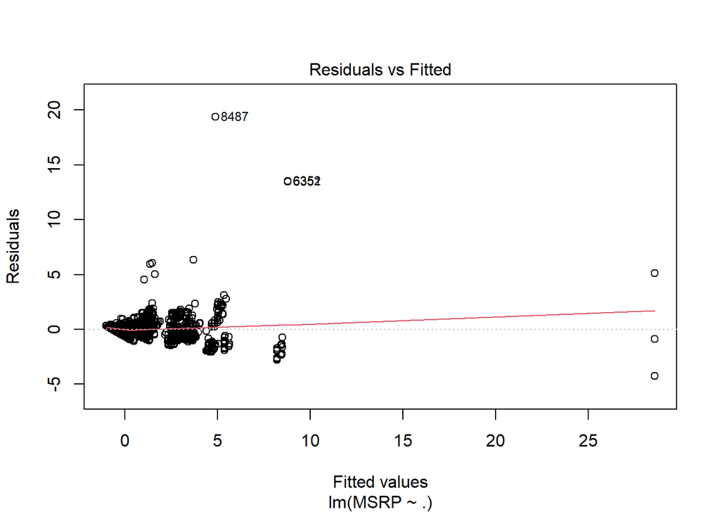

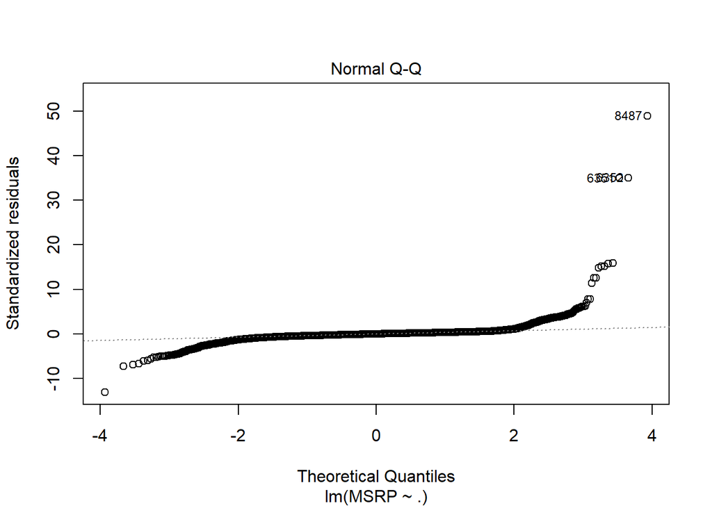

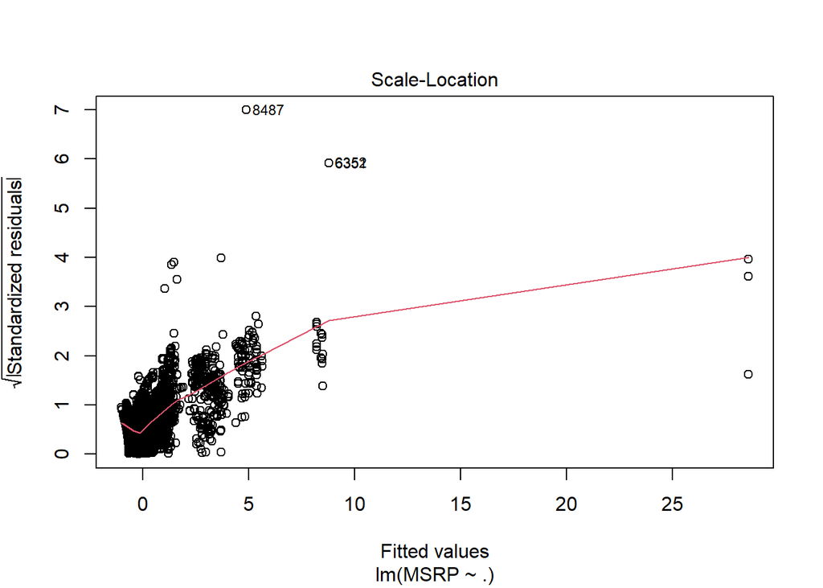

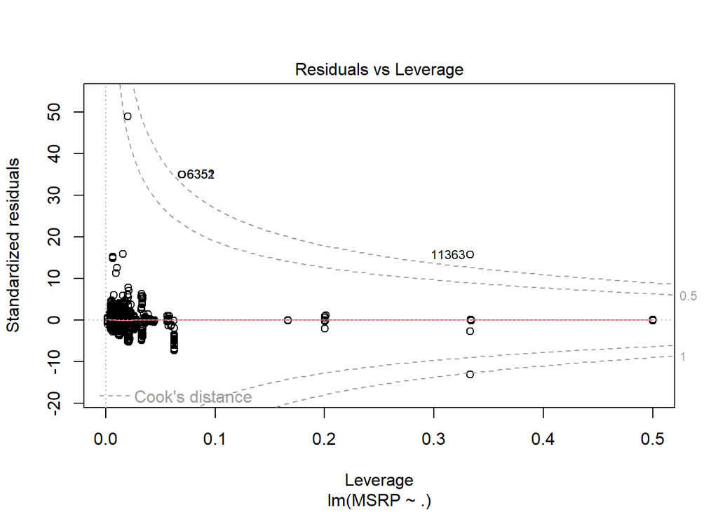

```r
plot(model_fit)
```